# Regla Única

# Weather Play ¿Cúando jugamos al golf?

Cargamos el conjunto de datos *WeatherPlayData.xlsx* de la hoja “Categorical”, fuerzamos la importacion a `data.frame` y observamos el contenido de su información.

```r
library(readxl)
weather.play<- read_excel("WeatherPlayData.xlsx",sheet = "Categorical")
weather.play<-as.data.frame(weather.play)
```

## ZeroR

ZeroR es el método de clasificación más sencillo que se basa en el objetivo e ignora todos los predictores. El clasificador ZeroR simplemente predice la categoría de mayoría (clase). Aunque no hay poder de predictibilidad en ZeroR, es útil para determinar el rendimiento base como punto de referencia para otros métodos de clasificación.

### Ejercicio

Determinamos el acierto aplicando el algoritmo ZeroR

```r
frq<-table(weather.play$Play)
max.frq <- which.max(frq)
model.zeror <- names(max.frq)
prediction<-rep(model.zeror,14)

table(prediction,weather.play$Play,useNA = "always",dnn=list("ZeroR","Play"))
```

```
      Play
ZeroR  no yes <NA>
  yes   5   9    0
  <NA>  0   0    0
```

```r
mean(prediction==weather.play$Play)*100
```

```
[1] 64.28571
```

```r
acierto.ZR<-mean(prediction==weather.play$Play)
```

## OneR package

OneR es una buena idea para construir “el mejor modelo simple” que logre un equilibrio entre la mejor precisión posible con un modelo que sea lo suficientemente simple de entender.

https://cran.r-project.org/web/packages/OneR/vignettes/OneR.html

### Frecuencias

Determinamos cómo se distribuye la Clase para cada Predictor y buscamos las reglas que mejor predicen según el algoritmo **OneR**.

```r
xtabs(~Outlook+Play,data=weather.play)
```

```
          Play
Outlook    no yes
  overcast  0   4
  rainy     2   3
  sunny     3   2
```

### One R

Construir el modelo con el mejor predictor utilzando el paquete **OneR**.

```r
library(OneR)
model <- OneR(Play~.,data=weather.play, verbose = TRUE) #,ties.method="chisq")
```

```
    Attribute   Accuracy
1 * Outlook     71.43%
1   Humidity    71.43%
3   Temperature 64.29%
3   Windy       64.29%
---
Chosen attribute due to accuracy
and ties method (if applicable): '*'
```

Mostrar reglas aprendidas y diagnóstico de modelo.

```r
summary(model)
```

```
Call:
OneR.formula(formula = Play ~ ., data = weather.play, verbose = TRUE)

Rules:
If Outlook = overcast then Play = yes
If Outlook = rainy    then Play = yes
If Outlook = sunny    then Play = no

Accuracy:
10 of 14 instances classified correctly (71.43%)

Contingency table:
     Outlook
Play  overcast rainy sunny Sum
  no         0     2   * 3   5
  yes      * 4   * 3     2   9
  Sum        4     5     5  14
---
Maximum in each column: '*'

Pearson's Chi-squared test:
X-squared = 3.5467, df = 2, p-value = 0.1698
```

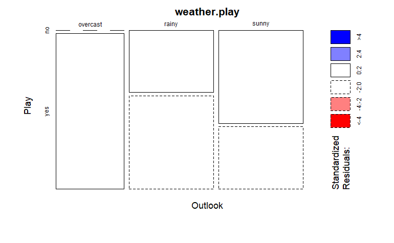

Predecimos con el modelo y evaluamos el rendimiento.

```r
prediction<-predict(model,weather.play)
OneR::eval_model(prediction,actual=weather.play$Play)#
```

[output not shown]

# Divorce Data Set

https://archive.ics.uci.edu/ml/datasets/Divorce+Predictors+data+set

**Attribute Information:**

1. If one of us apologizes when our discussion deteriorates, the discussion ends.  
2. I know we can ignore our differences, even if things get hard sometimes.  
3. When we need it, we can take our discussions with my spouse from the beginning and correct it.  
4. When I discuss with my spouse, to contact him will eventually work.  
5. The time I spent with my wife is special for us.  
6. We don’t have time at home as partners.  
7. We are like two strangers who share the same environment at home rather than family.  
8. I enjoy our holidays with my wife.  
9. I enjoy traveling with my wife.  
10. Most of our goals are common to my spouse.  
11. I think that one day in the future, when I look back, I see that my spouse and I have been in harmony with each other.  
12. My spouse and I have similar values in terms of personal freedom.  
13. My spouse and I have similar sense of entertainment.  
14. Most of our goals for people (children, friends, etc.) are the same.  
15. Our dreams with my spouse are similar and harmonious.  
16. We’re compatible with my spouse about what love should be.  
17. We share the same views about being happy in our life with my spouse  
18. My spouse and I have similar ideas about how marriage should be  
19. My spouse and I have similar ideas about how roles should be in marriage  
20. My spouse and I have similar values in trust.  
21. I know exactly what my wife likes.  
22. I know how my spouse wants to be taken care of when she/he sick.  
23. I know my spouse’s favorite food.  
24. I can tell you what kind of stress my spouse is facing in her/his life.  
25. I have knowledge of my spouse’s inner world.  
26. I know my spouse’s basic anxieties.  
27. I know what my spouse’s current sources of stress are.  
28. I know my spouse’s hopes and wishes.  
29. I know my spouse very well.  
30. I know my spouse’s friends and their social relationships.  
31. I feel aggressive when I argue with my spouse.  
32. When discussing with my spouse, I usually use expressions such as 'you always' or 'you never' .  
33. I can use negative statements about my spouse’s personality during our discussions.  
34. I can use offensive expressions during our discussions.  
35. I can insult my spouse during our discussions.  
36. I can be humiliating when we discussions.  
37. My discussion with my spouse is not calm.  
38. I hate my spouse’s way of open a subject.  
39. Our discussions often occur suddenly.  
40. We’re just starting a discussion before I know what’s going on.  
41. When I talk to my spouse about something, my calm suddenly breaks.  
42. When I argue with my spouse, ı only go out and I don’t say a word.  
43. I mostly stay silent to calm the environment a little bit.  
44. Sometimes I think it’s good for me to leave home for a while.  
45. I’d rather stay silent than discuss with my spouse.  
46. Even if I’m right in the discussion, I stay silent to hurt my spouse.  
47. When I discuss with my spouse, I stay silent because I am afraid of not being able to control my anger.  
48. I feel right in our discussions.  
49. I have nothing to do with what I’ve been accused of.  
50. I’m not actually the one who’s guilty about what I’m accused of.  
51. I’m not the one who’s wrong about problems at home.  
52. I wouldn’t hesitate to tell my spouse about her/his inadequacy.  
53. When I discuss, I remind my spouse of her/his inadequacy.  
54. I’m not afraid to tell my spouse about her/his incompetence.

`Class` debería ser un factor (aplica la lógica positiva!) y añade las etiquetas “yes” y “no”. ¿importa el orden de los niveles del factor?

```r
library(readxl)
data <- read_excel("divorce.xlsx")
data<-as.data.frame(data)
table(data$Class)
```

```
 0  1
86 84
```

```r
#solucion
data$Class <- factor(data$Class,levels=c(0,1),labels=c('yes','no'))
```

## ZeroR

Utiliza la función `confusionMatrix` del paquete `caret` para determinar el rendimiento del modelo **ZeroR**. ¿cómo se denomina al acierto del modelo **ZeroR** entre las medidas que ofrece `confusionMatrix`?

```r
library(caret)
moda <- function(x) {
   return(names(which.max(table(x))))
}
#solucion


moda_div<-moda(data$Class)

prediction<-rep(moda_div,dim(data)[1])

prediction_0 <- factor(prediction,levels=c('yes','no'))
confusionMatrix(prediction_0,data$Class)
```

```
Confusion Matrix and Statistics

          Reference
Prediction yes no
       yes  86 84
       no    0  0

               Accuracy : 0.5059
                 95% CI : (0.4283, 0.5833)
    No Information Rate : 0.5059
    P-Value [Acc > NIR] : 0.5307

                  Kappa : 0

 Mcnemar's Test P-Value : <2e-16

            Sensitivity : 1.0000
            Specificity : 0.0000
         Pos Pred Value : 0.5059
         Neg Pred Value :    NaN
             Prevalence : 0.5059
         Detection Rate : 0.5059
   Detection Prevalence : 1.0000
      Balanced Accuracy : 0.5000

       'Positive' Class : yes
```

## OneR

Discretiza los valores con la instrucción `bin` o `optbin` del paquete **OneR** para obtener el `data_disc`. ¿qué diferencia ambas funciones?

```r
library(OneR)
data_disc<-data
#solucion
data_disc <- optbin(Class~.,data=data_disc)
```

Utilizando la función **OneR** determina la regla que mejor estima el divorcio a partir de los datos discretizados `data_disc`.

```r
library(OneR)
#solucion
model <- OneR(Class~.,data=data_disc, verbose = TRUE)
```

```
    Attribute Accuracy
1 * Atr18     98.24%
2   Atr11     97.65%
2   Atr17     97.65%
2   Atr19     97.65%
5   Atr9      97.06%
5   Atr16     97.06%
5   Atr20     97.06%
5   Atr40     97.06%
9   Atr26     96.47%
10  Atr12     95.88%
10  Atr14     95.88%
10  Atr15     95.88%
10  Atr25     95.88%
10  Atr30     95.88%
```

[output cut: 43 more lines]

```r
summary(model)
```

```
Call:
OneR.formula(formula = Class ~ ., data = data_disc, verbose = TRUE)

Rules:
If Atr18 = (-0.004,1.19] then Class = yes
If Atr18 = (1.19,4]      then Class = no

Accuracy:
167 of 170 instances classified correctly (98.24%)

Contingency table:
     Atr18
Class (-0.004,1.19] (1.19,4] Sum
  yes          * 86        0  86
  no              3     * 81  84
  Sum            89       81 170
---
Maximum in each column: '*'

Pearson's Chi-squared test:
X-squared = 154.56, df = 1, p-value < 2.2e-16
```

Determina el rendimiento de la prueba con `confusionMatrix.` del paquete `caret`.

```r
# solucion
prediction <- predict(model,data_disc)
confusionMatrix(prediction,data$Class)
```

```
Confusion Matrix and Statistics

          Reference
Prediction yes no
       yes  86  3
       no    0 81

               Accuracy : 0.9824
                 95% CI : (0.9493, 0.9963)
    No Information Rate : 0.5059
    P-Value [Acc > NIR] : <2e-16

                  Kappa : 0.9647

 Mcnemar's Test P-Value : 0.2482

            Sensitivity : 1.0000
            Specificity : 0.9643
         Pos Pred Value : 0.9663
         Neg Pred Value : 1.0000
             Prevalence : 0.5059
         Detection Rate : 0.5059
   Detection Prevalence : 0.5235
      Balanced Accuracy : 0.9821

       'Positive' Class : yes
```